# Kyphosis Recurrence Predictor

## Compare and Analyse various Classifier Algorithms

## Problem Statement:

Given a DataSet of 81 patients who have undergone a spinal surgery for a deformation and the data if the condition recurred, Build a classification Model to predict whether a patient being admitted for the surgery has chance for recurrence. This model will help the surgeons to plan appropriate level of treatment to prevent recurrence.

## Data Set Description :

The kyphosis data frame has 81 rows and 4 columns representing data on children who have had corrective spinal surgery

This data frame contains the following columns/Features:

1. Kyphosis :a factor with levels absent present indicating if a kyphosis (a type of deformation) was present after the operation.
2. Age :in months
3. Number :the number of vertebrae involved
4. Start :the number of the first (topmost) vertebra operated on.

# Algorithms Suggested:

1.Decision Trees 2.Random Forest 3.KNN Classifier 4.Logistic Regression Let us compare the accuracy and suggest the best classifier.

# Import Libraries

```python
import pandas as pd
import seaborn as sns
import numpy as np
import matplotlib.pyplot as pl
%matplotlib inline
import warnings
warnings.filterwarnings('ignore')
```

# Get the Data

```python
df=pd.read_csv('C:\\Users\\Windows\\Desktop\\data sci\\06 Classification\\Kyphosis PY\\kyphosis.csv')
```

```python
df.head()
```

|  | Kyphosis | Age | Number | Start |
| --- | --- | --- | --- | --- |
| 0 | absent | 71 | 3 | 5 |
| 1 | absent | 158 | 3 | 14 |
| 2 | present | 128 | 4 | 5 |
| 3 | absent | 2 | 5 | 1 |
| 4 | absent | 1 | 4 | 15 |

# EDA

```python
df.describe()
```

|  | Age | Number | Start |
| --- | --- | --- | --- |
| count | 81.000000 | 81.000000 | 81.000000 |
| mean | 83.654321 | 4.049383 | 11.493827 |
| std | 58.104251 | 1.619423 | 4.883962 |
| min | 1.000000 | 2.000000 | 1.000000 |
| 25% | 26.000000 | 3.000000 | 9.000000 |
| 50% | 87.000000 | 4.000000 | 13.000000 |
| 75% | 130.000000 | 5.000000 | 16.000000 |
| max | 206.000000 | 10.000000 | 18.000000 |

```python
len(df)
```

```
81
```

```python
df.head(81)
```

|  | Kyphosis | Age | Number | Start |
| --- | --- | --- | --- | --- |
| 0 | absent | 71 | 3 | 5 |
| 1 | absent | 158 | 3 | 14 |
| 2 | present | 128 | 4 | 5 |
| 3 | absent | 2 | 5 | 1 |
| 4 | absent | 1 | 4 | 15 |
| 5 | absent | 1 | 2 | 16 |
| 6 | absent | 61 | 2 | 17 |
| 7 | absent | 37 | 3 | 16 |
| 8 | absent | 113 | 2 | 16 |
| 9 | present | 59 | 6 | 12 |
| 10 | present | 82 | 5 | 14 |
| 11 | absent | 148 | 3 | 16 |
| 12 | absent | 18 | 5 | 2 |
| 13 | absent | 1 | 4 | 12 |
| 14 | absent | 168 | 3 | 18 |
| 15 | absent | 1 | 3 | 16 |
| 16 | absent | 78 | 6 | 15 |
| 17 | absent | 175 | 5 | 13 |
| 18 | absent | 80 | 5 | 16 |
| 19 | absent | 27 | 4 | 9 |
| 20 | absent | 22 | 2 | 16 |
| 21 | present | 105 | 6 | 5 |
| 22 | present | 96 | 3 | 12 |
| 23 | absent | 131 | 2 | 3 |
| 24 | present | 15 | 7 | 2 |
| 25 | absent | 9 | 5 | 13 |
| 26 | absent | 8 | 3 | 6 |
| 27 | absent | 100 | 3 | 14 |
| 28 | absent | 4 | 3 | 16 |
| 29 | absent | 151 | 2 | 16 |
| ... | ... | ... | ... | ... |
| 51 | absent | 9 | 2 | 17 |
| 52 | present | 139 | 10 | 6 |
| 53 | absent | 2 | 2 | 17 |
| 54 | absent | 140 | 4 | 15 |
| 55 | absent | 72 | 5 | 15 |
| 56 | absent | 2 | 3 | 13 |
| 57 | present | 120 | 5 | 8 |
| 58 | absent | 51 | 7 | 9 |
| 59 | absent | 102 | 3 | 13 |
| 60 | present | 130 | 4 | 1 |
| 61 | present | 114 | 7 | 8 |
| 62 | absent | 81 | 4 | 1 |
| 63 | absent | 118 | 3 | 16 |
| 64 | absent | 118 | 4 | 16 |
| 65 | absent | 17 | 4 | 10 |
| 66 | absent | 195 | 2 | 17 |
| 67 | absent | 159 | 4 | 13 |
| 68 | absent | 18 | 4 | 11 |
| 69 | absent | 15 | 5 | 16 |
| 70 | absent | 158 | 5 | 14 |
| 71 | absent | 127 | 4 | 12 |
| 72 | absent | 87 | 4 | 16 |
| 73 | absent | 206 | 4 | 10 |
| 74 | absent | 11 | 3 | 15 |
| 75 | absent | 178 | 4 | 15 |
| 76 | present | 157 | 3 | 13 |
| 77 | absent | 26 | 7 | 13 |
| 78 | absent | 120 | 2 | 13 |
| 79 | present | 42 | 7 | 6 |
| 80 | absent | 36 | 4 | 13 |

81 rows × 4 columns

```python
df.info()
```

```
<class 'pandas.core.frame.DataFrame'>
RangeIndex: 81 entries, 0 to 80
Data columns (total 4 columns):
Kyphosis    81 non-null object
Age         81 non-null int64
Number      81 non-null int64
Start       81 non-null int64
dtypes: int64(3), object(1)
memory usage: 2.3+ KB
```

checking out a simple pairplot for this small dataset.

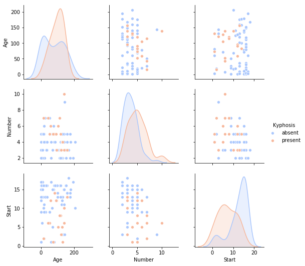

```python
sns.pairplot(df,hue='Kyphosis',palette='coolwarm')
```

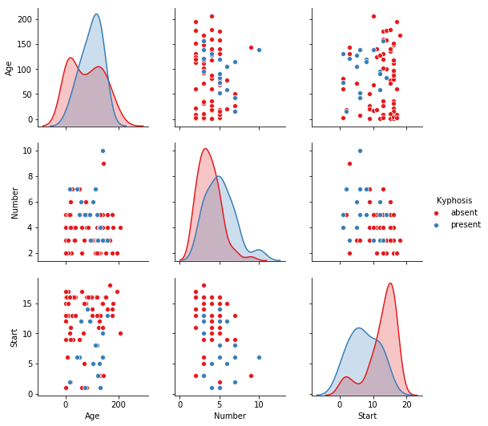

```python
sns.pairplot(df,hue='Kyphosis',palette='Set1')
```

# Train Test Split

Let's split up the data into a training set and a test set!

```python
from sklearn.model_selection import train_test_split
```

```python
x=df[['Age','Number','Start']]
print(x)
```

```
    Age  Number  Start
0    71       3      5
1   158       3     14
2   128       4      5
3     2       5      1
4     1       4     15
5     1       2     16
6    61       2     17
7    37       3     16
8   113       2     16
9    59       6     12
10   82       5     14
11  148       3     16
12   18       5      2
13    1       4     12
```

[output cut: 49 more lines]

```python
y=df['Kyphosis']
print(y)
```

```
0      absent
1      absent
2     present
3      absent
4      absent
5      absent
6      absent
7      absent
8      absent
9     present
10    present
11     absent
12     absent
13     absent
14     absent
```

[output cut: 47 more lines]

```python
x_train,x_test,y_train,y_test=train_test_split(x,y,test_size=0.3,random_state=69)
```

# DECISION TREES

```python
from sklearn.tree import DecisionTreeClassifier
dtree=DecisionTreeClassifier()
dtree.fit(x_train,y_train)
```

```
DecisionTreeClassifier(class_weight=None, criterion='gini', max_depth=None,
            max_features=None, max_leaf_nodes=None,
            min_impurity_decrease=0.0, min_impurity_split=None,
            min_samples_leaf=1, min_samples_split=2,
            min_weight_fraction_leaf=0.0, presort=False, random_state=None,
            splitter='best')
```

# Prediction and Evaluation

```python
predictions = dtree.predict(x_test)
```

```python
from sklearn.metrics import classification_report,confusion_matrix
```

```python
from sklearn.metrics import classification_report,confusion_matrix
```

```python
print(classification_report(y_test,predictions))
```

```
             precision    recall  f1-score   support

     absent       0.91      0.95      0.93        22
    present       0.50      0.33      0.40         3

avg / total       0.86      0.88      0.87        25
```

```python
print(confusion_matrix(y_test,predictions))
```

```
[[21  1]
 [ 2  1]]
```

# RANDOM FOREST

```python
from sklearn.ensemble import RandomForestClassifier
rfc=RandomForestClassifier(n_estimators=100)
rfc.fit(x_train,y_train)
```

```
RandomForestClassifier(bootstrap=True, class_weight=None, criterion='gini',
            max_depth=None, max_features='auto', max_leaf_nodes=None,
            min_impurity_decrease=0.0, min_impurity_split=None,
            min_samples_leaf=1, min_samples_split=2,
            min_weight_fraction_leaf=0.0, n_estimators=100, n_jobs=1,
            oob_score=False, random_state=None, verbose=0,
            warm_start=False)
```

Let's evaluate the Random Forest Classifier

```python
rf_predictions=rfc.predict(x_test)
```

```python
print(classification_report(y_test,rf_predictions))
```

```
             precision    recall  f1-score   support

     absent       0.88      0.95      0.91        22
    present       0.00      0.00      0.00         3

avg / total       0.77      0.84      0.80        25
```

```python
print(confusion_matrix(y_test,predictions))
```

```
[[21  1]
 [ 2  1]]
```

# LOGISTIC REGRESSION

```python
from sklearn.linear_model import LogisticRegression
logmodel = LogisticRegression()
logmodel.fit(x_train,y_train)
```

```
LogisticRegression(C=1.0, class_weight=None, dual=False, fit_intercept=True,
          intercept_scaling=1, max_iter=100, multi_class='ovr', n_jobs=1,
          penalty='l2', random_state=None, solver='liblinear', tol=0.0001,
          verbose=0, warm_start=False)
```

```python
LR_predictions = logmodel.predict(x_test)
```

```python
from sklearn.metrics import classification_report
print(classification_report(y_test,LR_predictions))
```

```
             precision    recall  f1-score   support

     absent       0.91      0.95      0.93        22
    present       0.50      0.33      0.40         3

avg / total       0.86      0.88      0.87        25
```

```python
print(confusion_matrix(y_test,LR_predictions))
```

```
[[21  1]
 [ 2  1]]
```

# KNN CLASSIFIER MODEL

KNN Needs to scale the Data before building the Model

```python
from sklearn.preprocessing import StandardScaler
scaler=StandardScaler()
scaler.fit(df[['Age','Number','Start']])
scaled_features=scaler.transform(df[['Age','Number','Start']])
new_df=pd.DataFrame(scaled_features)
new_df
new_df=pd.DataFrame(scaled_features,columns=['Age','Number','Start'])
new_df
```

|  | Age | Number | Start |
| --- | --- | --- | --- |
| 0 | -0.219143 | -0.652035 | -1.337907 |
| 1 | 1.287494 | -0.652035 | 0.516341 |
| 2 | 0.767964 | -0.030684 | -1.337907 |
| 3 | -1.414063 | 0.590667 | -2.162017 |
| 4 | -1.431381 | -0.030684 | 0.722368 |
| 5 | -1.431381 | -1.273387 | 0.928396 |
| 6 | -0.392320 | -1.273387 | 1.134423 |
| 7 | -0.807944 | -0.652035 | 0.928396 |
| 8 | 0.508199 | -1.273387 | 0.928396 |
| 9 | -0.426956 | 1.212019 | 0.104286 |
| 10 | -0.028649 | 0.590667 | 0.516341 |
| 11 | 1.114318 | -0.652035 | 0.928396 |
| 12 | -1.136980 | 0.590667 | -1.955990 |
| 13 | -1.431381 | -0.030684 | 0.104286 |
| 14 | 1.460671 | -0.652035 | 1.340451 |
| 15 | -1.431381 | -0.652035 | 0.928396 |
| 16 | -0.097920 | 1.212019 | 0.722368 |
| 17 | 1.581895 | 0.590667 | 0.310313 |
| 18 | -0.063284 | 0.590667 | 0.928396 |
| 19 | -0.981121 | -0.030684 | -0.513797 |
| 20 | -1.067710 | -1.273387 | 0.928396 |
| 21 | 0.369658 | 1.212019 | -1.337907 |
| 22 | 0.213798 | -0.652035 | 0.104286 |
| 23 | 0.819917 | -1.273387 | -1.749962 |
| 24 | -1.188933 | 1.833370 | -1.955990 |
| 25 | -1.292839 | 0.590667 | 0.310313 |
| 26 | -1.310157 | -0.652035 | -1.131880 |
| 27 | 0.283069 | -0.652035 | 0.516341 |
| 28 | -1.379428 | -0.652035 | 0.928396 |
| 29 | 1.166271 | -1.273387 | 0.928396 |
| ... | ... | ... | ... |
| 51 | -1.292839 | -1.273387 | 1.134423 |
| 52 | 0.958459 | 3.697424 | -1.131880 |
| 53 | -1.414063 | -1.273387 | 1.134423 |
| 54 | 0.975776 | -0.030684 | 0.722368 |
| 55 | -0.201826 | 0.590667 | 0.722368 |
| 56 | -1.414063 | -0.652035 | 0.310313 |
| 57 | 0.629423 | 0.590667 | -0.719825 |
| 58 | -0.565497 | 1.833370 | -0.513797 |
| 59 | 0.317705 | -0.652035 | 0.310313 |
| 60 | 0.802599 | -0.030684 | -2.162017 |
| 61 | 0.525517 | 1.833370 | -0.719825 |
| 62 | -0.045967 | -0.030684 | -2.162017 |
| 63 | 0.594787 | -0.652035 | 0.928396 |
| 64 | 0.594787 | -0.030684 | 0.928396 |
| 65 | -1.154298 | -0.030684 | -0.307769 |
| 66 | 1.928248 | -1.273387 | 1.134423 |
| 67 | 1.304812 | -0.030684 | 0.310313 |
| 68 | -1.136980 | -0.030684 | -0.101742 |
| 69 | -1.188933 | 0.590667 | 0.928396 |
| 70 | 1.287494 | 0.590667 | 0.516341 |
| 71 | 0.750646 | -0.030684 | 0.104286 |
| 72 | 0.057939 | -0.030684 | 0.928396 |
| 73 | 2.118743 | -0.030684 | -0.307769 |
| 74 | -1.258204 | -0.652035 | 0.722368 |
| 75 | 1.633848 | -0.030684 | 0.722368 |
| 76 | 1.270177 | -0.652035 | 0.310313 |
| 77 | -0.998439 | 1.833370 | 0.310313 |
| 78 | 0.629423 | -1.273387 | 0.310313 |
| 79 | -0.721356 | 1.833370 | -1.131880 |
| 80 | -0.825262 | -0.030684 | 0.310313 |

81 rows × 3 columns

```python
from sklearn.cross_validation import train_test_split
x=new_df
y=df['Kyphosis']
x_train,x_test,y_train,y_test=train_test_split(x,y,test_size=0.3,random_state=101)
```

```python
len(x_train)
```

```
56
```

# Elbow method to determine the optimal K value

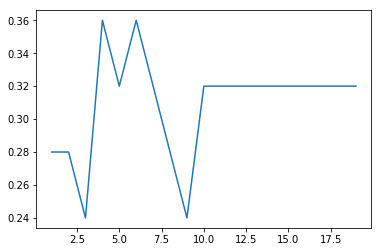

```python
from sklearn.neighbors import KNeighborsClassifier
error_rate=[]
for i in range(1,20):
    knn=KNeighborsClassifier(n_neighbors=i)
    knn.fit(x_train,y_train)
    pred_i=knn.predict(x_test)
    error_rate.append(np.mean(pred_i != y_test))

import matplotlib.pyplot as plt
plt.plot(range(1,20),error_rate)
```

# Build the Model with 3 as K

```python
knn=KNeighborsClassifier(n_neighbors=3)
knn.fit(x_train,y_train)
knn_predictions=knn.predict(x_test)
```

```python
print(confusion_matrix(y_test,knn_predictions))
```

```
[[16  1]
 [ 5  3]]
```

```python
print(classification_report(y_test,knn_predictions))
```

```
             precision    recall  f1-score   support

     absent       0.76      0.94      0.84        17
    present       0.75      0.38      0.50         8

avg / total       0.76      0.76      0.73        25
```

# Conclusion